# statistical_project

2024-05-27

# Project Introduction

In this project we aim to study the influence of selected macroeconomics indicators on the house price index in Colombia. This indicator measure the evolution through time of the market prices of residential properties. The idea of the analysis is to present and study the possible effects of the macroeconomics indicators on the house prices through the construction of regression models, evaluating their results and interpreting the models in the context of the data. This will help understand the main price drivers and could eventually help policy makers to provide an ecosystem for home affordability.

# Dataset Introduction and Preprocessing

The dataset was constructed gathering information from multiple sites: the Colombian department of statistics (DANE) , the Colombian central bank (Banco de la República), Google trends queries and the Federal Reserve Economic Data (FRED). In general, all the visited sites present the data as a .csv file with tables according to filters related with the time span of interest. With this we construct a consolidated database in .csv format with the following variables:

| Variable | Description |
| --- | --- |
| House Price Index | Measure of the average change in the residential properties price as an index |
| Industrial Inputs Index | Measure of the average changes in the industry input costs as an index |
| Metals Price Index | Measure of the average price change in metal costs excluding gold as an index |
| Energy Price Index | Measure of the average price change of energy including Crude oil, Natural Gas, Coal Price and Propane Indices |
| Shipping Price Index | Measure the average price change of shipping costs |
| Forex Index | Indicator of the foreign exchange rate of the Colombian Peso (COP) with respect of the USD |
| Unemployment Rate | Indicator of the percentage of unemployment population in Colombia |
| Industrial Production Index | Measure of the level of production on industrial sectors as an index |
| Interest rate | Reference interest rate emited by the colombian central bank with respect of the others financial institutions |
| Construction Licences Area | Measure the total of squared meters given for construction licences in Colombia |
| Finished Constructions | Measure of the total constructions that have been finished in Colombia |
| Google Trends Housing | Google search trends on housing for Colombia |

These variables present real values,and were selected as they have an initial coherent relation with the housing sector. Initially We present the import process of the data

# Data Uploading

```r
#Read the data using the read_excel function
#Change here for current data path
data <- read_excel("C:/Users/danie/Documents/GitHub/unipd_sl_24/data/data.xlsx",sheet = "dataframe_col")
```

# Data pre-processing and cleaning

After have an initial version of the data we proceed with the pre-processing and cleaning steps. As firs step we change the original variable names for more appropriate ones. Then we identify the number of NA values in each one of the columns.

```r
#change the variables names to have more consistency
colnames(data) <- c('MY','date','House_Price_Index','Industrial_Inputs_Index','Metals_Price_Index','Energy_Price_Index','Shipping_Price_Index','Forex_Index','Unemployment_Rate','Industrial_Production_Index','Interest_Rate','Construction_Licences_Area','Finished_Constructions','Google_Trends_Housing')
# Counting NA values in each column
na_counts <- apply(data, 2, function(x) sum(is.na(x)))
# Print the counts of NA values per column
print(na_counts)
```

```
##                          MY                        date
##                           0                           0
##           House_Price_Index     Industrial_Inputs_Index
##                           0                           0
##          Metals_Price_Index          Energy_Price_Index
##                           0                           0
##        Shipping_Price_Index                 Forex_Index
##                           0                           0
##           Unemployment_Rate Industrial_Production_Index
##                           0                          12
##               Interest_Rate  Construction_Licences_Area
##                           0                          12
##      Finished_Constructions       Google_Trends_Housing
##                         158                           0
```

```r
# Convert date column to Date type if it's not already
data$date <- as.Date(data$date)
# Copy the dataframe to avoid modifying the original one
data_filled <- data
```

We realize that the variable Finished_Constructions requires an additional pre-processing step because it is recorded by quarters while the others are registered by months. We propose the following reconstruction steps for those intermediate months. The idea is to take the quarterly value and divide it equally among the respective months of that quarter:

```r
# Find the indices where the date is at the end of a trimester
trimester_end_indices <- which(format(data$date, "%m") %in% c("03", "06", "09", "12"))
# Loop through each trimester end distribute the value
for (i in trimester_end_indices) {
  if (i - 2 > 0) {
    # Distribute the value to the current month and the previous two months
    value_to_distribute <- data$Finished_Constructions[i] / 3
    data_filled$Finished_Constructions[i] <- value_to_distribute
    data_filled$Finished_Constructions[i - 1] <- value_to_distribute
    data_filled$Finished_Constructions[i - 2] <- value_to_distribute
  }
}
data_filled$Finished_Constructions <- na.locf(data_filled$Finished_Constructions, na.rm = FALSE)
```

# Summary stats and final dataset

We proceed to remove the left rows with NA values eliminating from the dataset the registers before January 2005. Also, we drop the column MY also referred to the date in form of MONTH()YEAR(). Finally, we present an initial summary of the dataset after these transformations. In particular we see that the House Price Index range present values on [87.35,203.50] with an IQR=70.38.

```r
# Removing rows with any NA values
clean_data <- na.omit(data_filled)
# Drop MY column
data_reduced <- subset(clean_data, select = -c(MY))
```

```r
summary_stats <- summary(data_reduced[, !(names(data_reduced) %in% c("date"))])
```

| Statistic | Min | 1st Qu. | Median | Mean | 3rd Qu. | Max |
| --- | --- | --- | --- | --- | --- | --- |
| House_Price_Index | 87.35 | 110.50 | 157.92 | 147.71 | 180.88 | 203.50 |
| Industrial_Inputs_Index | 78.67 | 116.02 | 136.26 | 137.78 | 157.65 | 221.14 |
| Metals_Price_Index | 74.89 | 121.21 | 143.74 | 145.88 | 172.53 | 234.53 |
| Energy_Price_Index | 55.89 | 128.19 | 162.61 | 173.36 | 223.35 | 376.41 |
| Shipping_Price_Index | -213.3 | 242.2 | 262.1 | 280.7 | 294.1 | 478.3 |
| Forex_Index | 0.1712 | 1.1934 | 2.3762 | 2.6762 | 3.2021 | 4.9223 |
| Unemployment_Rate | 0.07563 | 0.09728 | 0.10970 | 0.11240 | 0.12099 | 0.21972 |
| Industrial_Production_Index | 59.82 | 77.94 | 94.44 | 92.87 | 104.85 | 132.46 |
| Interest_Rate | 0.01750 | 0.03860 | 0.04525 | 0.05551 | 0.06994 | 0.13250 |
| Construction_Licences_Area | 233210 | 969559 | 1156424 | 1205587 | 1373585 | 2883878 |
| Finished_Constructions | 471310 | 775374 | 848663 | 871488 | 962168 | 1335811 |
| Google_Trends_Housing | 16.00 | 23.50 | 34.75 | 36.04 | 47.62 | 64.00 |

# Outliers based on the IQR

As an initial step to better understand the data and its behavior we find the outliers of each one of the variables using the IQR to select those points outside the bounds. As a result we found that the variables that present the most quantity of outliers are the Shipping Price Index, the Interest Rate and the Unemployment Rate. In addition, we present the boxplot of these three variables to obtain a clear summary of their distribution.

```r
# Function to detect outliers based on IQR
detect_outliers_single_var <- function(column) {
  column <- na.omit(column)
  Q1 <- quantile(column, 0.25, na.rm = TRUE)
  Q3 <- quantile(column, 0.75, na.rm = TRUE)
  IQR <- Q3 - Q1
  lower_bound <- Q1 - 1.5 * IQR
  upper_bound <- Q3 + 1.5 * IQR
  outliers <- column[column < lower_bound | column > upper_bound]
  return(outliers)
}
# List to store outliers for each variable
outliers_list <- list()
# Loop to determine outliers in each column
for (var in colnames(data_reduced[, !(names(data_reduced) %in% c("date"))])) {
  if (is.numeric(data[[var]])) {
    outliers_list[[var]] <- detect_outliers_single_var(data[[var]])
  }
}
print(outliers_list)
```

| Variable | Values |
| --- | --- |
| House_Price_Index | 0 |
| Industrial_Inputs_Index | 0 |
| Metals_Price_Index | 0 |
| Energy_Price_Index | 376.4121 |
| Shipping_Price_Index | 374.969, 375.187, 395.268, 446.983, 439.181, 454.407, 468.721, 478.263, 478.216, 471.877, 469.290, 442.591, 456.584, 412.082, 409.599, 443.799, 420.694, 446.214, 462.462 |
| Forex_Index | 0 |
| Unemployment_Rate | 0.1725640, 0.2048530, 0.2197200, 0.2035910, 0.2091470, 0.1744270, 0.1629280, 0.1756237 |
| Industrial_Production_Index | 0 |
| Interest_Rate | 0.1141935, 0.1204839, 0.1275000, 0.1275806, 0.1300000, 0.1324194, 0.1325000, 0.1325000 |
| Construction_Licences_Area | 2493085, 1988396, 2838778, 2337743, 2331210, 2859035, 2372414, 2052607 |
| Finished_Constructions | 4007432, 3762696, 1413931 |
| Google_Trends_Housing | 0 |

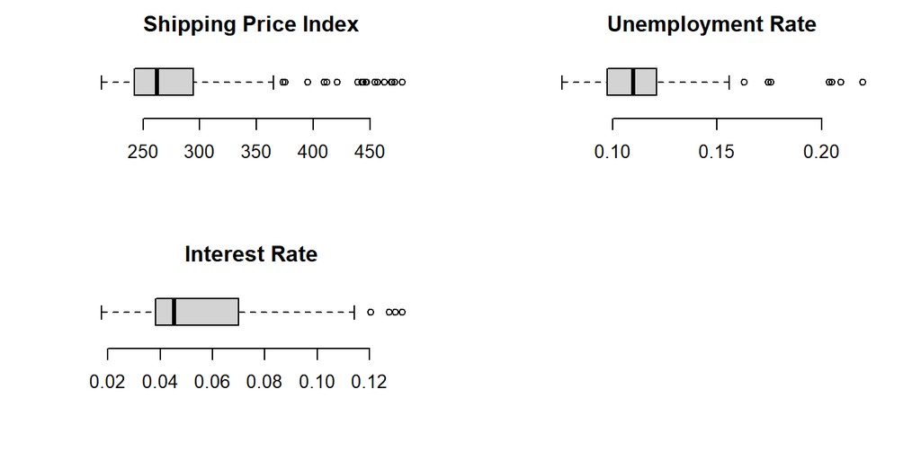

The outlier data for the shipping index, unemployment, and interest rates all relate to the COVID-19 shock. The shipping index crisis in mid-2022 resulted from the COVID-19 lockdowns (2020-2021), economic reactivation, and delays in Chinese and Western ports. The unemployment outliers are due to the initial COVID lockdown in Colombia and the ensuing economic shock. The high interest rates stem from the Colombian Central Bank’s efforts to control inflation starting in 2021.

# Ploting the House Price Index

Continuing with the exploratory analysis we plot the variable of House Price Index to see its behavior through time. It is possible to see a clear increase tendency starting from the year 2005 until the year 2021, then a little decay was recorded.

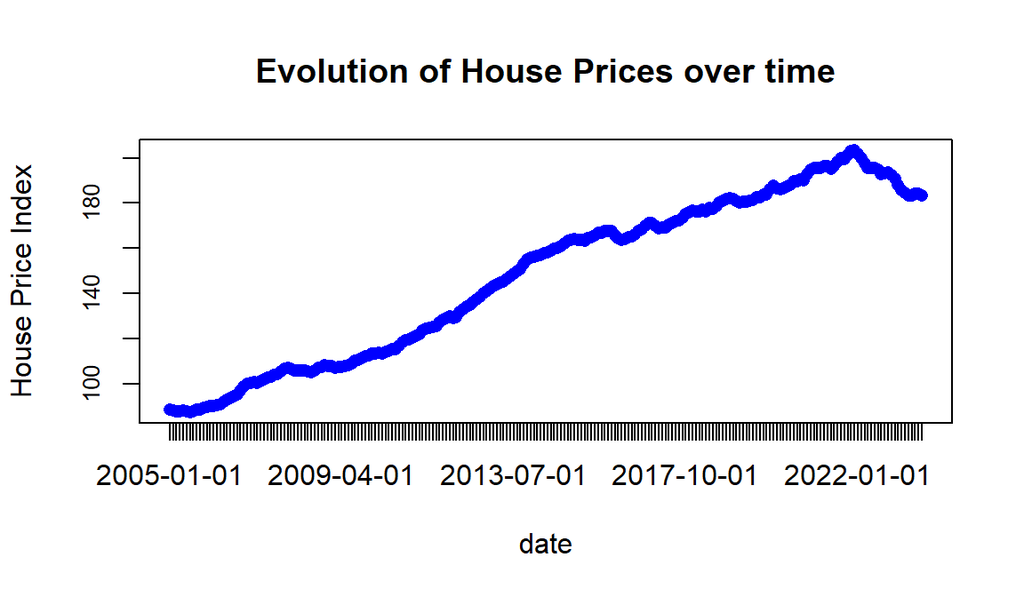

# Ploting percentual variation of the House Price Index

Further useful information can be found in the box plots and histograms for the percentual variations. We take the 12-period percentual variation of the variables with the intention of identify patterns and tendencies in a clear and interpretable way, considering that the majority of the variables are in index form, and the study of their changes is fundamental for a complete understanding of their behavior through time. We start with the House Price Index variable.

```r
# Select subset of variables to difference
variables_to_calculate <- c("House_Price_Index", "Industrial_Inputs_Index", "Metals_Price_Index",
                            "Energy_Price_Index", "Shipping_Price_Index", "Forex_Index",
                            "Industrial_Production_Index", "Construction_Licences_Area",
                            "Finished_Constructions", "Google_Trends_Housing")

# Create a function to calculate the 12-month percentual variation
percentual_variation_12_months <- function(x) {
  return((x / lag(x, n = 12) - 1))
}
lag <- function(x, n) {
  c(rep(NA, n), head(x, -n))
}
data_percentual_variation <- data
# Apply the function to the select variables
for (var in variables_to_calculate) {
  new_var_name <- paste0("pct_var_", var)
  data_percentual_variation[[new_var_name]] <- percentual_variation_12_months(data[[var]])
}
```

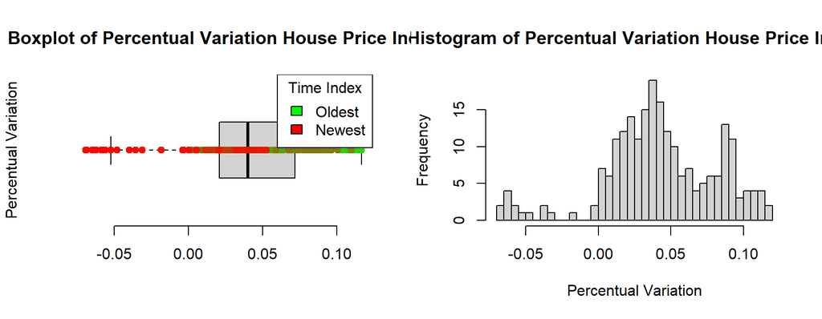

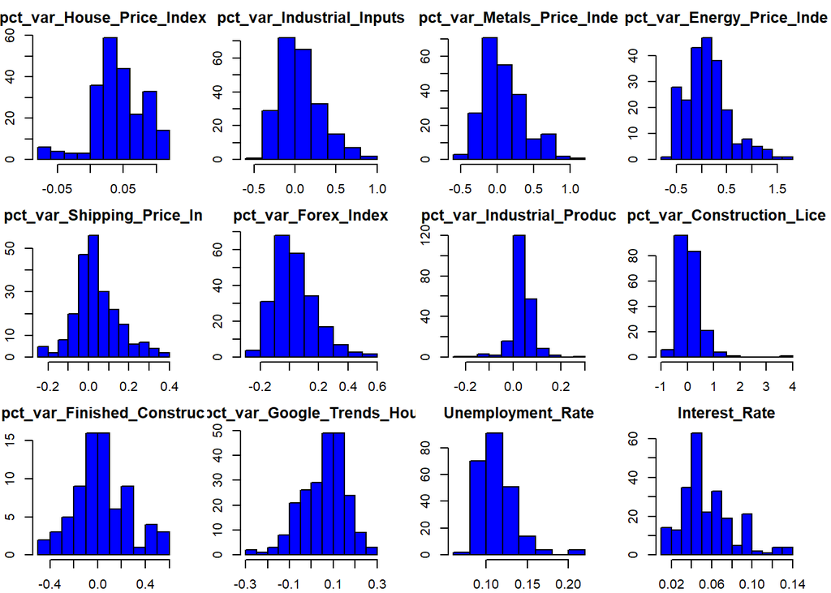

```r
{par(mfrow = c(3,4 ), mar = c(2, 2, 2, 2) + 0.1)
data_percentual_variation <- data_percentual_variation[, columns_to_select]
for (i in 1:ncol(data_percentual_variation)) {
  hist(data_percentual_variation[[i]],
       main = substr(names(data_percentual_variation)[i], 1, 25), # Shorten title if necessary
       xlab = names(data_percentual_variation)[i],
       col = "blue",
       border = "black")
}
}
```

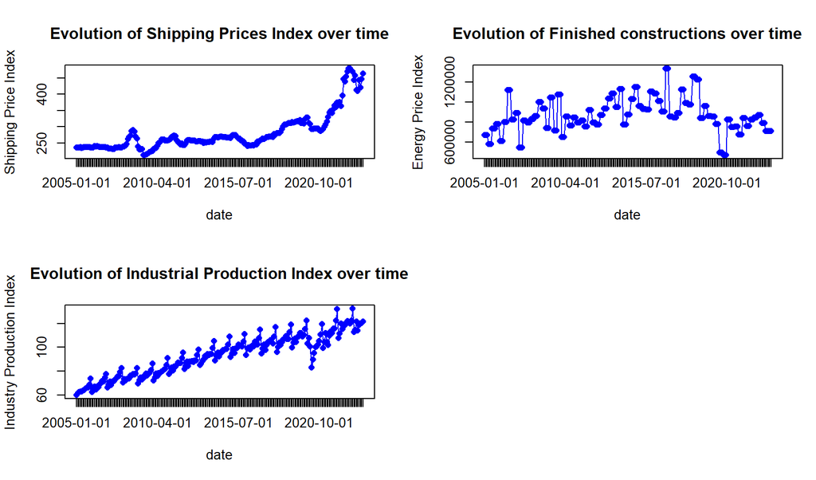

# Log-transformation

We apply a log transformation with the intention of scaling the data as some variables are index that change over time and others area real values with wider range. Our goal is to reduce the variability of the data, compressing the scale and helping to linearize those relationships between the variables for the interpretability of the results in the subsequent models. We apply log transformation to all variables except those that are already percentages: the Unemployment Rate and the Interest Rate.

```r
#Log transformation of the variables
variables_to_log <- c("House_Price_Index", "Industrial_Inputs_Index", "Metals_Price_Index",
                      "Energy_Price_Index", "Shipping_Price_Index", "Forex_Index",
                      "Industrial_Production_Index", "Construction_Licences_Area",
                      "Finished_Constructions", "Google_Trends_Housing")


for (var in variables_to_log) {
  log_var_name <- paste0(var, "_log")
  data_reduced[[log_var_name]] <- log(data_reduced[[var]])
}

# Subset the dataframe
selected_columns <- c(paste0(variables_to_log, "_log"), "Unemployment_Rate", "Interest_Rate")
data_final <- data_reduced[, selected_columns]
```

# Variable Correlation

Now we present the correlation between the variables of the dataset in order to understand the strength of their relation. We present the correlation matrix obtained. From the results we see a strong positive relationship between the House Price Index and the Google Trend and Industrial Production one,a more moderate correlation with the shipping Price and the Forex Index. While the weaker relationships are found with the Energy Price index and the Unemployment Rate.For the others variables, we found a high positive correlation between the metal price index and the industrial inputs.

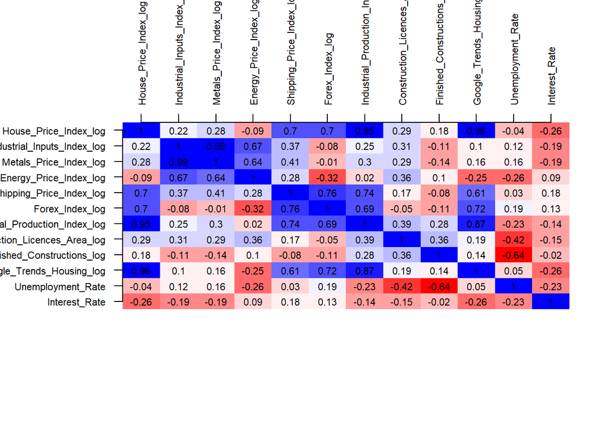

```r
# Plot the correlation matrix

{par(mar = c(7, 7, 7, 2) + 0.1)
cor_matrix<-correl_matrix
image(1:ncol(cor_matrix), 1:nrow(cor_matrix), t(cor_matrix)[, ncol(cor_matrix):1],
      axes = FALSE, xlab = "", ylab = "", col = colorRampPalette(c("red", "white", "blue"))(20))

# Add axis labels
axis(3, at = 1:ncol(cor_matrix), labels = colnames(cor_matrix), las = 2, cex.axis = 0.7)
axis(2, at = 1:nrow(cor_matrix), labels = rev(rownames(cor_matrix)), las = 2, cex.axis = 0.7)

#correlation coefficients
for (i in 1:ncol(cor_matrix)) {
  for (j in 1:nrow(cor_matrix)) {
    text(i, nrow(cor_matrix) - j + 1, round(cor_matrix[i, j], 2), cex = 0.7)
  }
}}
```

# Multicolinearity Check

Now present a multicollinearity test in top of the results related with the correlation of the variables in relation with the dependent variable of House Price Index. We first calculate the VIF for each predictor variable. We found that some variables like Shipping, Industrial Production Index, Metals Price Index and Industrial Inputs present a high VIF.

```
##     Industrial_Inputs_Index_log          Metals_Price_Index_log
##                      232.372573                      237.983290
##          Energy_Price_Index_log        Shipping_Price_Index_log
##                        6.176604                       12.188511
##                 Forex_Index_log Industrial_Production_Index_log
##                       10.143101                       17.856757
##  Construction_Licences_Area_log      Finished_Constructions_log
##                        1.807047                        2.148915
##       Google_Trends_Housing_log               Unemployment_Rate
##                        8.171922                        4.286584
##                   Interest_Rate
##                        1.982209
```

At this point we consider to remove the Metals Price Index as they show a strong correlation with Industrial Inputs, they both have a similar behavior and at the end the metal sector is considered on the Industrial Inputs Index. After this reduction we re run the VIF test. There are some variables that show high VIF, but due to the economic literature we decide to keep going with them. Later we will perform variable selection through different approaches and eventually the multicolinearity here present will be corrected.

```
##     Industrial_Inputs_Index_log          Energy_Price_Index_log
##                        3.479427                        6.171898
##        Shipping_Price_Index_log                 Forex_Index_log
##                       11.954143                       10.092636
## Industrial_Production_Index_log  Construction_Licences_Area_log
##                       14.752680                        1.698461
##      Finished_Constructions_log       Google_Trends_Housing_log
##                        2.102236                        8.037613
##               Unemployment_Rate                   Interest_Rate
##                        3.673045                        1.900964
```

# Train Test Split

Before proceed with the linear models we apply a train test split in order to have a test set to compare the performance in a fair way between the data. For this we implement the following steps, considering that our train set will be 80% of the data:

```r
set.seed(123)
# sample index for training data
trainIndex <- sample(seq_len(nrow(data_final)), size = 0.8 * nrow(data_final))
# Split the data into training and testing sets
data_train <- data_final[trainIndex, ]
data_test <- data_final[-trainIndex, ]

X_train <- model.matrix(House_Price_Index_log ~ ., data = data_train)[, -1]
y_train <- data_train$House_Price_Index_log
X_test <- model.matrix(House_Price_Index_log ~ ., data = data_test)[, -1]
y_test <- data_test$House_Price_Index_log
```

# Modelling the data

#Initial full linear model We start with a simple regression model for the data, remember that this process will be executed with the variables after the log normalization. In this first iteration we consider all the explanatory variables.

```r
# OLS 1 Log-Log-----------------
# Perform linear regression
model <- lm(House_Price_Index_log ~ ., data = data_train)
summary(model)
```

```
##
## Call:
## lm(formula = House_Price_Index_log ~ ., data = data_train)
##
## Residuals:
##       Min        1Q    Median        3Q       Max
## -0.088670 -0.019984  0.001724  0.019942  0.092810
##
## Coefficients:
##                                 Estimate Std. Error t value Pr(>|t|)
## (Intercept)                      0.79395    0.31588   2.513 0.012898 *
## Industrial_Inputs_Index_log     -0.03332    0.01994  -1.671 0.096516 .
## Energy_Price_Index_log           0.01794    0.01808   0.992 0.322477
## Shipping_Price_Index_log         0.07971    0.04815   1.656 0.099658 .
## Forex_Index_log                 -0.07641    0.02797  -2.732 0.006973 **
## Industrial_Production_Index_log  0.80968    0.05384  15.040  < 2e-16 ***
## Construction_Licences_Area_log  -0.02418    0.01060  -2.282 0.023760 *
## Finished_Constructions_log      -0.01036    0.01879  -0.551 0.582041
## Google_Trends_Housing_log        0.32995    0.01873  17.620  < 2e-16 ***
## Unemployment_Rate                0.76654    0.23145   3.312 0.001134 **
## Interest_Rate                   -0.47954    0.12981  -3.694 0.000298 ***
## ---
## Signif. codes:  0 '***' 0.001 '**' 0.01 '*' 0.05 '.' 0.1 ' ' 1
##
## Residual standard error: 0.03321 on 168 degrees of freedom
## Multiple R-squared:  0.9846, Adjusted R-squared:  0.9837
## F-statistic:  1075 on 10 and 168 DF,  p-value: < 2.2e-16
```

In this first model we see a high R-squared, this mean that the model is powerful in terms of explain the variability in the House Price Index, but the model is no completely satisfactory as it includes several predictors without statistical significance, and other with different degree of significance as Industrial Production Index, Google Trends Housing and Interest Rate. This can be explain because the R-squared statistic will always increase when more variables are added to the model. We proceed to plot the the results for the fitted results and the QQ-plot of the residuals:

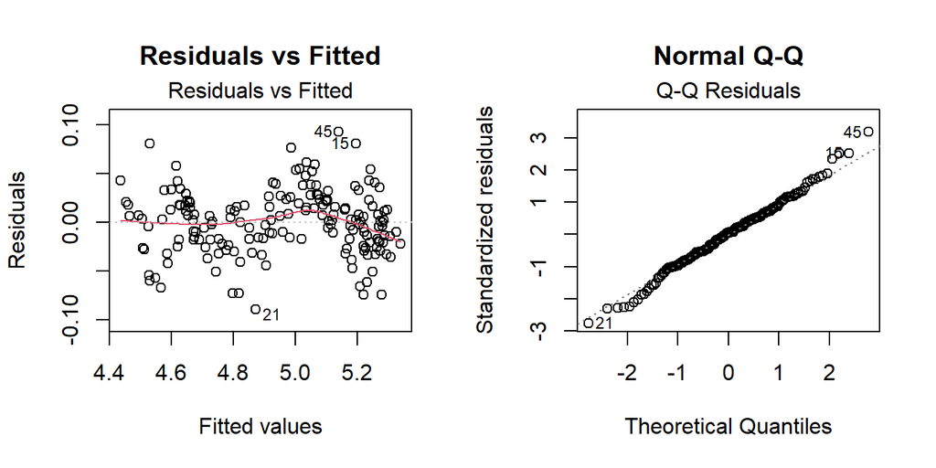

```
## [1] 0.00186722
```

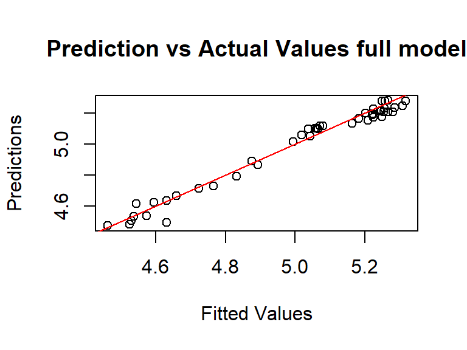

# Model dropping variables according to their significance

```
##
## Call:
## lm(formula = House_Price_Index_log ~ ., data = data_train)
##
## Residuals:
##       Min        1Q    Median        3Q       Max
## -0.088670 -0.019984  0.001724  0.019942  0.092810
##
## Coefficients:
##                                 Estimate Std. Error t value Pr(>|t|)
## (Intercept)                      0.79395    0.31588   2.513 0.012898 *
## Industrial_Inputs_Index_log     -0.03332    0.01994  -1.671 0.096516 .
## Energy_Price_Index_log           0.01794    0.01808   0.992 0.322477
## Shipping_Price_Index_log         0.07971    0.04815   1.656 0.099658 .
## Forex_Index_log                 -0.07641    0.02797  -2.732 0.006973 **
## Industrial_Production_Index_log  0.80968    0.05384  15.040  < 2e-16 ***
## Construction_Licences_Area_log  -0.02418    0.01060  -2.282 0.023760 *
## Finished_Constructions_log      -0.01036    0.01879  -0.551 0.582041
## Google_Trends_Housing_log        0.32995    0.01873  17.620  < 2e-16 ***
## Unemployment_Rate                0.76654    0.23145   3.312 0.001134 **
## Interest_Rate                   -0.47954    0.12981  -3.694 0.000298 ***
## ---
## Signif. codes:  0 '***' 0.001 '**' 0.01 '*' 0.05 '.' 0.1 ' ' 1
##
## Residual standard error: 0.03321 on 168 degrees of freedom
## Multiple R-squared:  0.9846, Adjusted R-squared:  0.9837
## F-statistic:  1075 on 10 and 168 DF,  p-value: < 2.2e-16
```

|  | Res.Df | RSS | Df | Sum of Sq | F | Pr(>F) |
| --- | --- | --- | --- | --- | --- | --- |
| 1 | 169 | 0.1864257 | NA | NA | NA | NA |
| 2 | 168 | 0.1853394 | 1 | 0.001086291 | 0.9846632 | 0.3224773 |

We observe again the significance of the variables, and the next no significant variables that we decide to drop were Industrial Inputs Index, Finished Constructions. All of this after eliminating step by step each one following the previous procedure with the ANOVA F-test until all the predictors show statistical evidence of having coefficient different from 0.

```r
#Process of Variable dropping according to ther significance

# Energy does not improve model
summary(red.mod)
red.mod2 <- update(red.mod, . ~ . -Industrial_Inputs_Index_log)
anova(red.mod, red.mod2)
# Can safely remove industrial inputs log
summary(red.mod2)

# Remove finished_constructions_log
red.mod3 <- update(red.mod2, . ~ . -Finished_Constructions_log)
anova(red.mod2, red.mod3)
# Can safely remove finished constructions (but makes no sense)
summary(red.mod3)
```

```
##
## Call:
## lm(formula = House_Price_Index_log ~ Shipping_Price_Index_log +
##     Forex_Index_log + Industrial_Production_Index_log + Construction_Licences_Area_log +
##     Google_Trends_Housing_log + Unemployment_Rate + Interest_Rate,
##     data = data_train)
##
## Residuals:
##       Min        1Q    Median        3Q       Max
## -0.094159 -0.021217 -0.000685  0.021851  0.090717
##
## Coefficients:
##                                 Estimate Std. Error t value Pr(>|t|)
## (Intercept)                      0.64293    0.16678   3.855 0.000164 ***
## Shipping_Price_Index_log         0.09061    0.02805   3.231 0.001481 **
## Forex_Index_log                 -0.06931    0.01801  -3.849 0.000167 ***
## Industrial_Production_Index_log  0.77431    0.04870  15.901  < 2e-16 ***
## Construction_Licences_Area_log  -0.02490    0.01038  -2.399 0.017496 *
## Google_Trends_Housing_log        0.33191    0.01750  18.968  < 2e-16 ***
## Unemployment_Rate                0.61628    0.18912   3.259 0.001351 **
## Interest_Rate                   -0.46996    0.12859  -3.655 0.000342 ***
## ---
## Signif. codes:  0 '***' 0.001 '**' 0.01 '*' 0.05 '.' 0.1 ' ' 1
##
## Residual standard error: 0.03321 on 171 degrees of freedom
## Multiple R-squared:  0.9843, Adjusted R-squared:  0.9837
## F-statistic:  1535 on 7 and 171 DF,  p-value: < 2.2e-16
```

```
## [1] 0.001830836
```

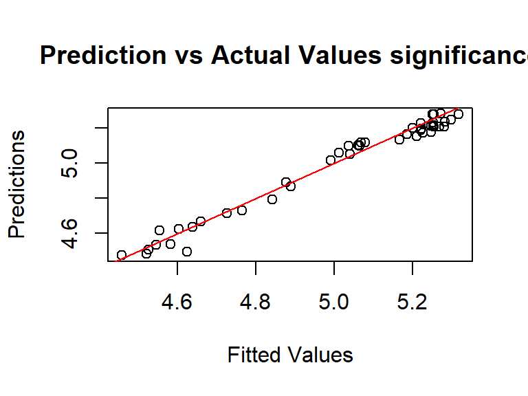

# Model with lagged variable

```r
# Using a a lag version of the House Price Index

data_final_with_lag<- data_final

data_final_with_lag$House_Price_Index_log_lag1 <- c(NA, head(data_final$House_Price_Index_log, -1))

data_final_with_lag <- na.omit(data_final_with_lag)
```

```r
# Set the seed for reproducibility
set.seed(123)

trainIndex_lag <- sample(seq_len(nrow(data_final_with_lag)), size = 0.8 * nrow(data_final_with_lag))

# Split the data into training and testing sets
data_train_lag <- data_final_with_lag[trainIndex_lag, ]
data_test_lag <- data_final_with_lag[-trainIndex_lag, ]


X_train_lag <- model.matrix(House_Price_Index_log ~ ., data = data_train_lag)[, -1]
y_train_lag <- data_train_lag$House_Price_Index_log


X_test_lag <- model.matrix(House_Price_Index_log ~ ., data = data_test_lag)[, -1]
y_test_lag <- data_test_lag$House_Price_Index_log
```

```r
model_lag <- lm(House_Price_Index_log ~ House_Price_Index_log_lag1 +Forex_Index_log+Industrial_Production_Index_log+Construction_Licences_Area_log+Google_Trends_Housing_log+Interest_Rate, data = data_train_lag)

# Summarize the model
summary(model_lag)
```

```
##
## Call:
## lm(formula = House_Price_Index_log ~ House_Price_Index_log_lag1 +
##     Forex_Index_log + Industrial_Production_Index_log + Construction_Licences_Area_log +
##     Google_Trends_Housing_log + Interest_Rate, data = data_train_lag)
##
## Residuals:
##       Min        1Q    Median        3Q       Max
## -0.011794 -0.002766  0.000083  0.003037  0.015861
##
## Coefficients:
##                                  Estimate Std. Error t value Pr(>|t|)
## (Intercept)                      0.110388   0.023991   4.601 8.15e-06 ***
## House_Price_Index_log_lag1       0.963768   0.009419 102.321  < 2e-16 ***
## Forex_Index_log                 -0.009077   0.002165  -4.193 4.40e-05 ***
## Industrial_Production_Index_log  0.037624   0.008286   4.540 1.06e-05 ***
## Construction_Licences_Area_log  -0.003591   0.001491  -2.408   0.0171 *
## Google_Trends_Housing_log        0.008054   0.004049   1.989   0.0483 *
## Interest_Rate                   -0.079478   0.017003  -4.674 5.96e-06 ***
## ---
## Signif. codes:  0 '***' 0.001 '**' 0.01 '*' 0.05 '.' 0.1 ' ' 1
##
## Residual standard error: 0.00486 on 171 degrees of freedom
## Multiple R-squared:  0.9997, Adjusted R-squared:  0.9996
## F-statistic: 8.361e+04 on 6 and 171 DF,  p-value: < 2.2e-16
```

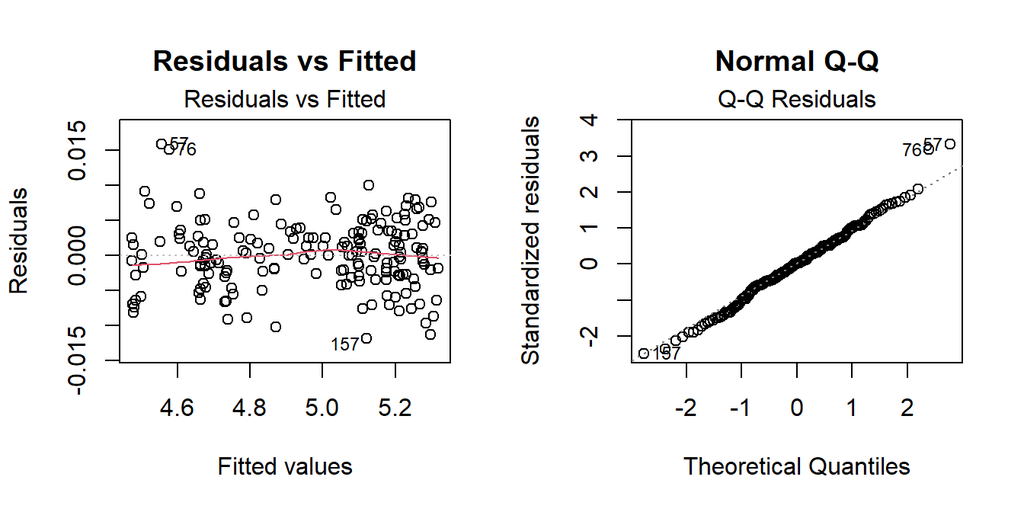

Now, it is possible to see that the fit of the predictions and actual values is more correct, in terms that it follows almost a a perfect straight line.

```
## [1] 2.317564e-05
```

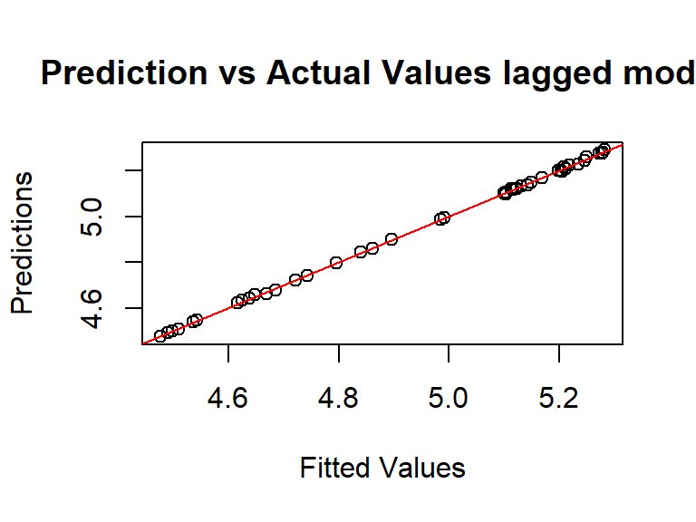

# Forward AIC Selection model

```r
# Forward AIC Stepwise selection-------------

# Fit the null model (intercept only)
null_model <- lm(House_Price_Index_log ~ 1, data = data_train)

# Specify the full model with all potential predictors
full_model <- lm(House_Price_Index_log ~ Industrial_Inputs_Index_log + Shipping_Price_Index_log + Forex_Index_log + Industrial_Production_Index_log +
                   Construction_Licences_Area_log + Google_Trends_Housing_log +
                   Unemployment_Rate + Interest_Rate, data = data_train)

# Perform forward selection based on AIC
forward_model <- step(null_model,
                      scope = list(lower = null_model, upper = full_model),
                      direction = "forward")
```

```
##
## Call:
## lm(formula = House_Price_Index_log ~ Google_Trends_Housing_log +
##     Industrial_Production_Index_log + Interest_Rate + Unemployment_Rate +
##     Forex_Index_log + Shipping_Price_Index_log + Construction_Licences_Area_log,
##     data = data_train)
##
## Residuals:
##       Min        1Q    Median        3Q       Max
## -0.094159 -0.021217 -0.000685  0.021851  0.090717
##
## Coefficients:
##                                 Estimate Std. Error t value Pr(>|t|)
## (Intercept)                      0.64293    0.16678   3.855 0.000164 ***
## Google_Trends_Housing_log        0.33191    0.01750  18.968  < 2e-16 ***
## Industrial_Production_Index_log  0.77431    0.04870  15.901  < 2e-16 ***
## Interest_Rate                   -0.46996    0.12859  -3.655 0.000342 ***
## Unemployment_Rate                0.61628    0.18912   3.259 0.001351 **
## Forex_Index_log                 -0.06931    0.01801  -3.849 0.000167 ***
## Shipping_Price_Index_log         0.09061    0.02805   3.231 0.001481 **
## Construction_Licences_Area_log  -0.02490    0.01038  -2.399 0.017496 *
## ---
## Signif. codes:  0 '***' 0.001 '**' 0.01 '*' 0.05 '.' 0.1 ' ' 1
##
## Residual standard error: 0.03321 on 171 degrees of freedom
## Multiple R-squared:  0.9843, Adjusted R-squared:  0.9837
## F-statistic:  1535 on 7 and 171 DF,  p-value: < 2.2e-16
```

```
## [1] 0.001830836
```

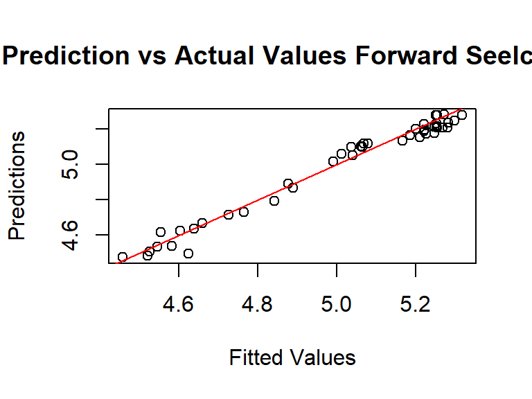

# Backward AIC selection model

We also implemented backward selection based on the AIC obtained from various models. We start from the full model then variables are removed based on the AIC. As a result, the outcomes matched those previously obtained in the forward selection approach.

```r
# Backward AIC Stepwise selection-------------

full_model <- lm(House_Price_Index_log ~ Industrial_Inputs_Index_log + Shipping_Price_Index_log + Forex_Index_log + Industrial_Production_Index_log +
                   Construction_Licences_Area_log + Google_Trends_Housing_log +
                   Unemployment_Rate + Interest_Rate, data = data_train)

# Perform backward selection based on AIC
backward_model <- step(full_model,
                       direction = "backward")
```

```
##
## Call:
## lm(formula = House_Price_Index_log ~ Shipping_Price_Index_log +
##     Forex_Index_log + Industrial_Production_Index_log + Construction_Licences_Area_log +
##     Google_Trends_Housing_log + Unemployment_Rate + Interest_Rate,
##     data = data_train)
##
## Residuals:
##       Min        1Q    Median        3Q       Max
## -0.094159 -0.021217 -0.000685  0.021851  0.090717
##
## Coefficients:
##                                 Estimate Std. Error t value Pr(>|t|)
## (Intercept)                      0.64293    0.16678   3.855 0.000164 ***
## Shipping_Price_Index_log         0.09061    0.02805   3.231 0.001481 **
## Forex_Index_log                 -0.06931    0.01801  -3.849 0.000167 ***
## Industrial_Production_Index_log  0.77431    0.04870  15.901  < 2e-16 ***
## Construction_Licences_Area_log  -0.02490    0.01038  -2.399 0.017496 *
## Google_Trends_Housing_log        0.33191    0.01750  18.968  < 2e-16 ***
## Unemployment_Rate                0.61628    0.18912   3.259 0.001351 **
## Interest_Rate                   -0.46996    0.12859  -3.655 0.000342 ***
## ---
## Signif. codes:  0 '***' 0.001 '**' 0.01 '*' 0.05 '.' 0.1 ' ' 1
##
## Residual standard error: 0.03321 on 171 degrees of freedom
## Multiple R-squared:  0.9843, Adjusted R-squared:  0.9837
## F-statistic:  1535 on 7 and 171 DF,  p-value: < 2.2e-16
```

# Lasso regresion model

As an alternative approach, we decided to implement the Lasso regression model. Our goal is to obtain a model that shrinks the coefficients of the variables, thereby reducing overfitting. Another aim is to evaluate whether some coefficients of the explanatory variables are set to zero. To achieve this, we use cross-validation to train the model.

```r
library(glmnet)
# Fit LASSO regression model
lasso_model <- cv.glmnet(X_train, y_train, alpha = 1)  # alpha = 1 for LASSO
lasso_best_lambda <- lasso_model$lambda.min
lasso_predictions <- predict(lasso_model, s = lasso_best_lambda, newx = X_test)
actuals <- y_test
```

```r
# Coefficients at best lambda
lasso_coefficients <- coef(lasso_model, s = lasso_best_lambda)
print(lasso_coefficients)
```

```
## 11 x 1 sparse Matrix of class "dgCMatrix"
##                                           s1
## (Intercept)                      0.741327314
## Industrial_Inputs_Index_log     -0.022369516
## Energy_Price_Index_log           0.018196124
## Shipping_Price_Index_log         0.065335787
## Forex_Index_log                 -0.059385694
## Industrial_Production_Index_log  0.787242512
## Construction_Licences_Area_log  -0.022814422
## Finished_Constructions_log      -0.008274111
## Google_Trends_Housing_log        0.332610292
## Unemployment_Rate                0.674629707
## Interest_Rate                   -0.486292194
```

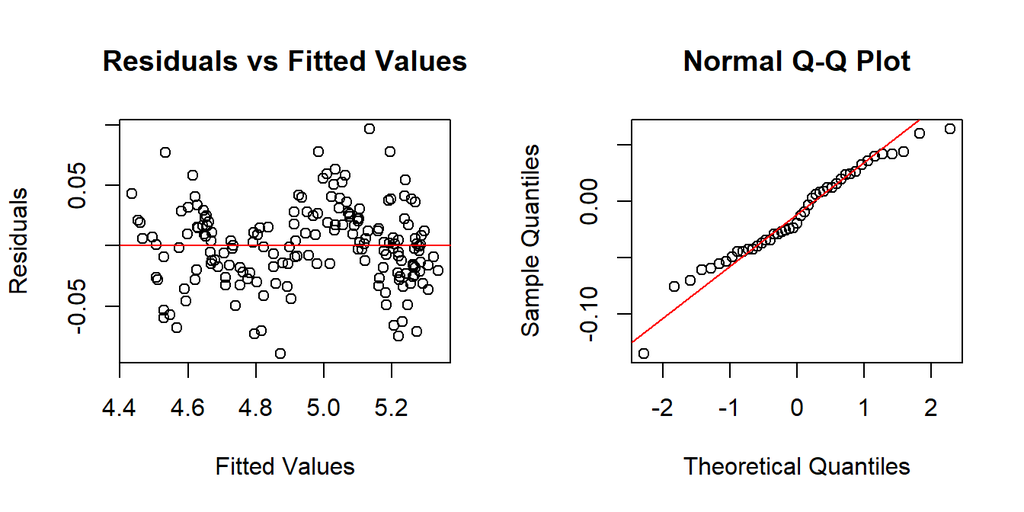

```r
# Calculate the Mean Squared Error (MSE)
mse_lasso <- mean((lasso_predictions - y_test)^2)
print(paste("Mean Squared Error:", mse_lasso))
```

```
## [1] "Mean Squared Error: 0.00183252365342529"
```

```r
# Calculate R-squared (R2)
y_mean <- mean(y_test)
ss_total <- sum((y_test - y_mean)^2)
ss_residual <- sum((y_test - lasso_predictions)^2)
r2 <- 1 - (ss_residual / ss_total)
print(paste("R-squared:", r2))
```

```
## [1] "R-squared: 0.974974383706247"
```

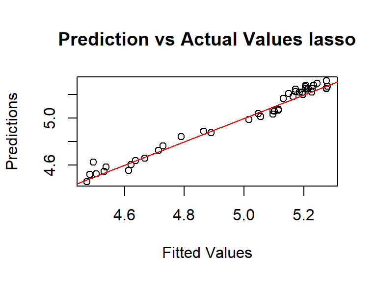

```r
{
plot(actuals,predictions,main = "Prediction vs Actual Values lasso",
     xlab = "Fitted Values", ylab = "Predictions")
abline(0, 1, col = "red")}
```

# Ridge regression model

We applied a similar procedure for Ridge regression to assess whether it produces a different model compared to Lasso, given its distinct regularization term. The results are presented above:

```r
# Regularization------------
# Done over full model

# Fit RIDGE regression model
ridge_model <- cv.glmnet(X_train, y_train, alpha = 0)  # alpha = 0 for Ridge
ridge_best_lambda <- ridge_model$lambda.min
ridge_predictions <- predict(ridge_model, s = ridge_best_lambda, newx = X_test)
actuals <- y_test
```

```r
# Coefficients at best lambda
ridge_coefficients <- coef(ridge_model, s = ridge_best_lambda)
print(ridge_coefficients)
```

```
## 11 x 1 sparse Matrix of class "dgCMatrix"
##                                           s1
## (Intercept)                     -0.144744114
## Industrial_Inputs_Index_log      0.034484853
## Energy_Price_Index_log          -0.012393077
## Shipping_Price_Index_log         0.140560512
## Forex_Index_log                  0.039961309
## Industrial_Production_Index_log  0.553919098
## Construction_Licences_Area_log  -0.002977282
## Finished_Constructions_log       0.031146341
## Google_Trends_Housing_log        0.304693425
## Unemployment_Rate               -0.026640711
## Interest_Rate                   -0.923398135
```

In general we get a different results for the coefficients with Ridge. It is possible to see that some of them change drastically as for example the one for the Unemployment Rate.In the Lasso approach Unemployment Rate has a positive high value, while with Ridge we obtained a negative small one. According to economic theory, the sign of Unemployment should be negative, because as Unemployment goes up, there should be less available income for the families, reducing the demand for new homes, thus having a negative impact on the final price of new homes. So the Ridge coefficient makes more sense.

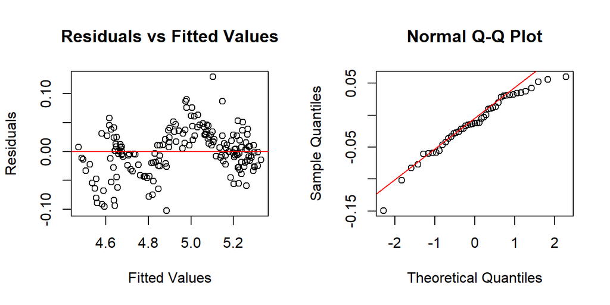

```r
# Calculate the Mean Squared Error (MSE)
mse_ridge <- mean((ridge_predictions - y_test)^2)
print(paste("Mean Squared Error:", mse_ridge))
```

```
## [1] "Mean Squared Error: 0.00209622139939288"
```

```r
# Calculate R-squared (R2)
y_mean <- mean(y_test)
ss_total <- sum((y_test - y_mean)^2)
ss_residual <- sum((y_test - ridge_predictions)^2)
r2 <- 1 - (ss_residual / ss_total)
print(paste("R-squared:", r2))
```

```
## [1] "R-squared: 0.971373230402836"
```

[figure not shown]

```r
{
plot(actuals,predictions,main = "Prediction vs Actual Values Ridge",
     xlab = "Fitted Values", ylab = "Predictions")
abline(0, 1, col = "red")}
```

#MSE Model comparison

| Variable | Value |
| --- | --- |
| mse_full | 1.867e-3 |
| mse_red | 1.830e-3 |
| mse_lag | 0.0231e-3 |
| mse_forward | 1.830e-3 |
| mse_backward | 1.830e-3 |
| mse_lasso | 1.832e-3 |
| mse_ridge | 2.096e-3 |

It is evident that the best model in terms of MSE is the one using the lagged dependent variable as a predictor. Compared to the others, most models provide similar values for the coefficients of the explanatory variables. In general, the reduced model obtained with only the statistically significant variables and the one implemented using AIC-based selection perform similarly. The Lasso and Ridge regularization techniques yield similar results, with Ridge having a slightly higher MSE but more reasonable signs for its coefficients.

# Statistical Inference - Best Model

Based on the model with the lowest MSE, we now proceed to interpret the coefficients of the covariates. All variables have a p-value indicating statistical significance at least at the 5% level. The log-transformation of the variables that were not percentages is handy as it allows us to interpret the log-log effects as the impact of a 1% increase in variable X on the House Price Index by B%.

In this model, the variable with the highest coefficient is the lagged House Price Index. This aligns with the economic theory of price stickiness and the inflationary spiral. A 1% increase in the House Price Index results in a 0.96% increase for the next month, indicating high inflationary persistence. It is important to note that durable goods tend to have stickier prices. The second coefficient we observe is for Forex, showing that a 1% increase in the foreign exchange rate reduces the House Price Index by 0.009%. This coefficient is almost negligible, which makes sense since the instantaneous effect on house prices is minimal.

Next, we observe the Industrial Production Index, where a 1% increase results in a 0.03% increase in the House Price Index. This makes sense as a more dynamic economy typically leads to higher demand for housing, thus increasing prices. For the Construction Licenses Area, a 1% increase results in a 0.003% decrease in the House Price Index. This aligns with economic theory, where an increase in available housing area should lead to an increase in supply, thereby reducing prices.

The Google Trends Index shows an effect of 0.008%, indicating that the intention to buy a house, or at least the related searches, positively impacts the dependent variable. This is notable because this indicator can be obtained in real time, unlike the others and can help predict the direction of housing prices in advance. Lastly, for the Interest Rate, a 1% increase leads to a 0.07% decrease in prices. This is because higher interest rates make consumers less likely to take on credit, thereby reducing the demand for new houses and consequently lowering prices.

For further studies, different lags for the explanatory variables could be added to determine which have the most impact on the House Price Index. While this is beyond the scope of this report, it could be useful for government policy-making based on statistical evidence. This way, housing prices can be managed more effectively, contributing to the long-term wealth of the population.